[Edit on GitHub](https://github.com/JuliaManifolds/Manopt.jl/blob/main/nothing)

# Illustration of the Gradient of a Second Order Difference

This example explains how to compute the gradient of the second order difference midpoint model using `adjoint_Jacobi_field`.

This example also illustrates the `PowerManifold` manifold as well as `ArmijoLinesearch`.

```julia
using Manopt, Manifolds, Colors, PlutoUI
```

We define some colors from [Paul Tol](https://personal.sron.nl/~pault/)

```julia
begin
    black = RGBA{Float64}(colorant"#000000")
    TolVibrantBlue = RGBA{Float64}(colorant"#0077BB")
    TolVibrantOrange = RGBA{Float64}(colorant"#EE7733")
    TolVibrantMagenta = RGBA{Float64}(colorant"#EE3377")
    TolVibrantCyan = RGBA{Float64}(colorant"#33BBEE")
    TolVibrantTeal = RGBA{Float64}(colorant"#009988")
end;
```

```julia
begin
    T = [0:0.1:1.0...]
    #render asy yes/no. If not, images included w/ markdown are assumed to be prerendered
    render_asy = false
    localpath = join(splitpath(@__FILE__)[1:(end - 1)], "/") # remove file to get files folder
    image_prefix = localpath * "/second_order_difference"
    @info image_prefix
end;
```

Assume we have two points $p,q$ on the equator of the [Sphere](https://juliamanifolds.github.io/Manifolds.jl/stable/manifolds/sphere.html)$\mathcal M = \mathbb S^2$ and a point $r$ near the north pole

```julia
begin
    M = Sphere(2)
    p = [1.0, 0.0, 0.0]
    q = [0.0, 1.0, 0.0]
    c = mid_point(M, p, q)
    r = shortest_geodesic(M, [0.0, 0.0, 1.0], c, 0.1)
end;
```

Now the second order absolute difference can be stated as [BacakBergmannSteidlWeinmann2016]

$$d_2(p_1,p:2,p_3) := \min_{c ∈ \mathcal C_{p_1,p_3}} d_{\mathcal M}(c,p_2),\qquad p_1,p_2,p_3∈\mathcal M,$$

where $\mathcal C_{p,q}$ is the set of all midpoints $g(\frac{1}{2};p,q)$, between `p`and `q`, i.e. where $g$ is a (not necessarily minimizing) geodesic connecting both.

For illustration we further define the point opposite of the midpoint `c` defined above

```julia
c2 = -c;
```

To illustrate the second order difference let's look at the geodesic connecting $r$ and the midpoint $c$

```julia
geoPts_rc = shortest_geodesic(M, r, c, T);
```

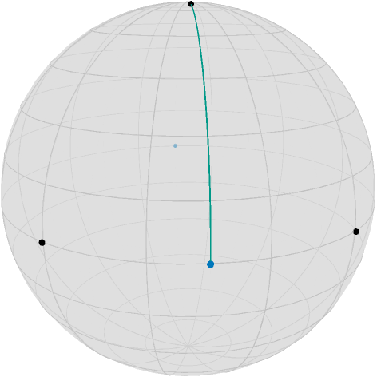

```julia
render_asy && begin
    asymptote_export_S2_signals(
        image_prefix * "/SecondOrderData.asy";
        curves=[geoPts_rc],
        points=[[p, r, q], [c, c2]],
        colors=Dict(:curves => [TolVibrantTeal], :points => [black, TolVibrantBlue]),
        dot_size=3.5,
        line_width=0.75,
        camera_position=(1.2, 1.0, 0.5), #src
    )
    render_asymptote(image_prefix * "/SecondOrderData.asy"; render=2)
end;
```

**Figure.***The three (black) points $p, q$, and $r$ (near the north pole), which is connected by a geodesic (teal) to the midpoint of the first two, $c$ (blue). The length of this geodesic is the cost of the second order total variation.*

Since we moved $r$ 10% along the geodesic from the north pole to $c$, the distance to $c$ is $\frac{9\pi}{20}\approx 1.4137$, and this is also what the second order total variation cost, see [`costTV2`](https://manoptjl.org/stable/functions/costs.html#Manopt.costTV2), yields:

```julia
costTV2(M, (p, r, q))
```

```
1.413716694115407
```

But also its gradient can be easily computed since it is just a distance with respect to $r$ and a concatenation of a geodesic, where the start or end point is the argument, respectively, with a distance. Hence the adjoint differentials [`adjoint_differential_geodesic_startpoint`](https://manoptjl.org/stable/functions/adjointdifferentials.html#Manopt.adjoint_differential_geodesic_startpoint-Tuple{AbstractManifold,%20Any,%20Any,%20Any,%20Any}) and [`adjoint_differential_geodesic_endpoint`](https://manoptjl.org/stable/functions/adjointdifferentials.html#Manopt.adjoint_differential_geodesic_endpoint-Tuple{AbstractManifold,%20Any,%20Any,%20Any,%20Any}) can be employed. The gradient is also directly implemented, see [`grad_TV2`](https://manoptjl.org/stable/functions/gradients.html#Manopt.grad_TV2). We obtain

```julia
(Xp, Xr, Xq) = grad_TV2(M, (p, r, q))
```

```
3-element Vector{Vector{Float64}}:
 [-0.0, -4.9676995583751974e-18, -0.7071067811865475]
 [-0.6984011233337103, -0.6984011233337102, 0.15643446504023084]
 [4.9676995583751974e-18, 0.0, -0.7071067811865475]
```

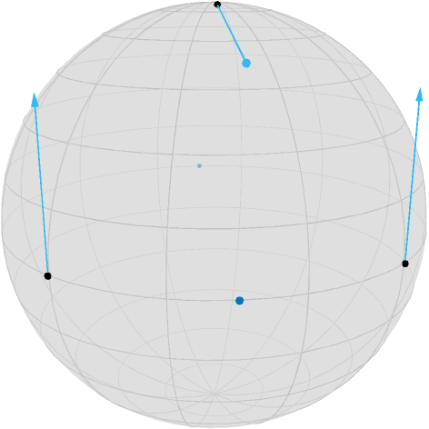

```julia
render_asy && begin
    asymptote_export_S2_signals(
        image_prefix * "/SecondOrderGradient.asy";
        points=[[p, r, q], [c, c2]],
        tangent_vectors=[Tuple.([[p, -Xp], [r, -Xr], [q, -Xq]])],
        colors=Dict(:tvectors => [TolVibrantCyan], :points => [black, TolVibrantBlue]),
        dot_size=3.5,
        line_width=0.75,
        camera_position=(1.2, 1.0, 0.5),
    )
    render_asymptote(image_prefix * "/SecondOrderGradient.asy"; render=2)
end;
```

**Figure.***The negative gradient of the second order difference cost indicates the movement of the three points in order to reduce their cost.*

If we now perform a gradient step with constant step size 1, we obtain the three points

```julia
pn, rn, qn = exp.(Ref(M), [p, r, q], [-Xp, -Xr, -Xq])
```

```
3-element Vector{Vector{Float64}}:
 [0.7602445970756302, 4.563951614149274e-18, 0.6496369390800624]
 [0.6474502912317517, 0.6474502912317516, 0.4020152245473301]
 [-4.563951614149274e-18, 0.7602445970756302, 0.6496369390800624]
```

as well we the new midpoint

[output not shown]

Let's also again consider the geodesic connecting the new point $r_n$ and the new midpoint $c_n$, as well as the gradient

```julia
begin
    geoPts_rncn = shortest_geodesic(M, rn, cn, T)
    (Xpn, Xrn, Xqn) = grad_TV2(M, (pn, rn, qn))
end;
```

The new configuration of the three points looks as follows

```julia
render_asy && begin
    asymptote_export_S2_signals(
        image_prefix * "/SecondOrderMin1.asy";
        points=[[p, r, q], [c, c2, cn], [pn, rn, qn]],
        curves=[geoPts_rncn],
        tangent_vectors=[
            Tuple.([[p, -Xp], [r, -Xr], [q, -Xq]]),
            Tuple.([[pn, -Xpn], [rn, -Xrn], [qn, -Xqn]]),
        ],
        colors=Dict(
            :tvectors => [TolVibrantCyan, TolVibrantMagenta],
            :points => [black, TolVibrantBlue, TolVibrantOrange],
            :curves => [TolVibrantTeal],
        ),
        dot_size=3.5,
        line_width=0.75,
        camera_position=(1.2, 1.0, 0.5),
    )
    render_asymptote(image_prefix * "/SecondOrderMin1.asy"; render=2)
end;
```

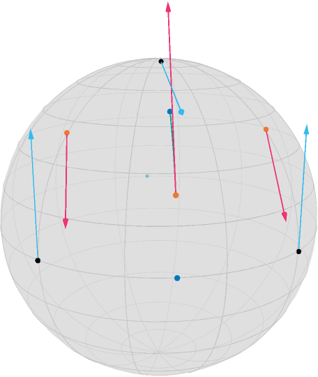

```julia
PlutoUI.LocalResource(image_prefix * "/SecondOrderMin1.png")
```

One can see that this step slightly “overshoots”, i.e. $r$ is now even below $c$, and the cost function is still at

```julia
costTV2(M, (pn, rn, qn))
```

```
0.46579428818288565
```

But we can also search for the best step size using `linesearch_backtrack` on the `PowerManifold` manifold $\mathcal N = \mathcal M^3 = (\mathbb S^2)^3$

```julia
begin
    x = [p, r, q]
    N = PowerManifold(M, NestedPowerRepresentation(), 3)
    s = linesearch_backtrack(N, x -> costTV2(N, x), x, grad_TV2(N, x), 1.0, 0.957, 0.999)
end
```

```
0.7362738857656108
```

and we obtain the new points

```julia
begin
    pm, rm, qm = exp.(Ref(M), [p, r, q], s * [-Xp, -Xr, -Xq])
    cm = mid_point(M, pm, qm)
    geoPts_pmqm = shortest_geodesic(M, pm, qm, T)
end;
```

we obtain

```julia
render_asy && begin
    asymptote_export_S2_signals(
        image_prefix * "/SecondOrderMin2.asy";
        points=[[p, r, q], [c, c2, cm], [pm, rm, qm]],
        curves=[geoPts_pmqm],
        tangent_vectors=[Tuple.([[p, -Xp], [r, -Xr], [q, -Xq]])],
        colors=Dict(
            :tvectors => [TolVibrantCyan],
            :points => [black, TolVibrantBlue, TolVibrantOrange],
            :curves => [TolVibrantTeal],
        ),
        dot_size=3.5,
        line_width=0.75,
        camera_position=(1.2, 1.0, 0.5),
    )
    render_asymptote(image_prefix * "/SecondOrderMin2.asy"; render=2)
end;
```

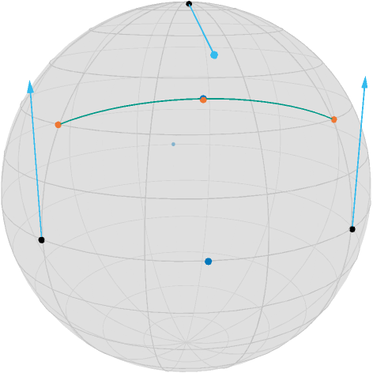

```julia
PlutoUI.LocalResource(image_prefix * "/SecondOrderMin2.png")
```

**Figure.***For the best step size found by line search, $r_m$ and $c_m$ nearly agree, i.e. $r_m$ lies on the geodesic between $p_m$ and $q_m$ as the geodesic drawn here indicates.*

Here, the cost function yields

```julia
costTV2(M, (pm, rm, qm))
```

```
0.003907643132786784
```

which is much closer to zero, as one can also see, since the new center $c_m$ and $r_m$ are quite close.

## Literature

BacakBergmannSteidlWeinmann2016

> Bačák, M., Bergmann, R., Steidl, G. and Weinmann, A.: *A second order nonsmooth variational model for restoring manifold-valued images*, SIAM Journal on Scientific Computations, Volume 38, Number 1, pp. A567–597, doi: 10.1137/15M101988X, arXiv: 1506.02409